# HW1P3

```python
import pandas as pd
```

```python
df = pd.read_csv('./Auto-cleaned.csv')
```

```python
df
```

|  | Unnamed: 0 | mpg | cylinders | displacement | horsepower | weight | acceleration | year | origin | name |
| --- | --- | --- | --- | --- | --- | --- | --- | --- | --- | --- |
| 0 | 0 | 18.0 | 8 | 307.0 | 130.0 | 3504 | 12.0 | 70 | 1 | chevrolet chevelle malibu |
| 1 | 1 | 15.0 | 8 | 350.0 | 165.0 | 3693 | 11.5 | 70 | 1 | buick skylark 320 |
| 2 | 2 | 18.0 | 8 | 318.0 | 150.0 | 3436 | 11.0 | 70 | 1 | plymouth satellite |
| 3 | 3 | 16.0 | 8 | 304.0 | 150.0 | 3433 | 12.0 | 70 | 1 | amc rebel sst |
| 4 | 4 | 17.0 | 8 | 302.0 | 140.0 | 3449 | 10.5 | 70 | 1 | ford torino |
| 5 | 5 | 15.0 | 8 | 429.0 | 198.0 | 4341 | 10.0 | 70 | 1 | ford galaxie 500 |
| 6 | 6 | 14.0 | 8 | 454.0 | 220.0 | 4354 | 9.0 | 70 | 1 | chevrolet impala |
| 7 | 7 | 14.0 | 8 | 440.0 | 215.0 | 4312 | 8.5 | 70 | 1 | plymouth fury iii |
| 8 | 8 | 14.0 | 8 | 455.0 | 225.0 | 4425 | 10.0 | 70 | 1 | pontiac catalina |
| 9 | 9 | 15.0 | 8 | 390.0 | 190.0 | 3850 | 8.5 | 70 | 1 | amc ambassador dpl |
| 10 | 10 | 15.0 | 8 | 383.0 | 170.0 | 3563 | 10.0 | 70 | 1 | dodge challenger se |
| 11 | 11 | 14.0 | 8 | 340.0 | 160.0 | 3609 | 8.0 | 70 | 1 | plymouth 'cuda 340 |
| 12 | 12 | 15.0 | 8 | 400.0 | 150.0 | 3761 | 9.5 | 70 | 1 | chevrolet monte carlo |
| 13 | 13 | 14.0 | 8 | 455.0 | 225.0 | 3086 | 10.0 | 70 | 1 | buick estate wagon (sw) |
| 14 | 14 | 24.0 | 4 | 113.0 | 95.0 | 2372 | 15.0 | 70 | 3 | toyota corona mark ii |
| 15 | 15 | 22.0 | 6 | 198.0 | 95.0 | 2833 | 15.5 | 70 | 1 | plymouth duster |
| 16 | 16 | 18.0 | 6 | 199.0 | 97.0 | 2774 | 15.5 | 70 | 1 | amc hornet |
| 17 | 17 | 21.0 | 6 | 200.0 | 85.0 | 2587 | 16.0 | 70 | 1 | ford maverick |
| 18 | 18 | 27.0 | 4 | 97.0 | 88.0 | 2130 | 14.5 | 70 | 3 | datsun pl510 |
| 19 | 19 | 26.0 | 4 | 97.0 | 46.0 | 1835 | 20.5 | 70 | 2 | volkswagen 1131 deluxe sedan |
| 20 | 20 | 25.0 | 4 | 110.0 | 87.0 | 2672 | 17.5 | 70 | 2 | peugeot 504 |
| 21 | 21 | 24.0 | 4 | 107.0 | 90.0 | 2430 | 14.5 | 70 | 2 | audi 100 ls |
| 22 | 22 | 25.0 | 4 | 104.0 | 95.0 | 2375 | 17.5 | 70 | 2 | saab 99e |
| 23 | 23 | 26.0 | 4 | 121.0 | 113.0 | 2234 | 12.5 | 70 | 2 | bmw 2002 |
| 24 | 24 | 21.0 | 6 | 199.0 | 90.0 | 2648 | 15.0 | 70 | 1 | amc gremlin |
| 25 | 25 | 10.0 | 8 | 360.0 | 215.0 | 4615 | 14.0 | 70 | 1 | ford f250 |
| 26 | 26 | 10.0 | 8 | 307.0 | 200.0 | 4376 | 15.0 | 70 | 1 | chevy c20 |
| 27 | 27 | 11.0 | 8 | 318.0 | 210.0 | 4382 | 13.5 | 70 | 1 | dodge d200 |
| 28 | 28 | 9.0 | 8 | 304.0 | 193.0 | 4732 | 18.5 | 70 | 1 | hi 1200d |
| 29 | 29 | 27.0 | 4 | 97.0 | 88.0 | 2130 | 14.5 | 71 | 3 | datsun pl510 |
| ... | ... | ... | ... | ... | ... | ... | ... | ... | ... | ... |
| 362 | 367 | 28.0 | 4 | 112.0 | 88.0 | 2605 | 19.6 | 82 | 1 | chevrolet cavalier |
| 363 | 368 | 27.0 | 4 | 112.0 | 88.0 | 2640 | 18.6 | 82 | 1 | chevrolet cavalier wagon |
| 364 | 369 | 34.0 | 4 | 112.0 | 88.0 | 2395 | 18.0 | 82 | 1 | chevrolet cavalier 2-door |
| 365 | 370 | 31.0 | 4 | 112.0 | 85.0 | 2575 | 16.2 | 82 | 1 | pontiac j2000 se hatchback |
| 366 | 371 | 29.0 | 4 | 135.0 | 84.0 | 2525 | 16.0 | 82 | 1 | dodge aries se |
| 367 | 372 | 27.0 | 4 | 151.0 | 90.0 | 2735 | 18.0 | 82 | 1 | pontiac phoenix |
| 368 | 373 | 24.0 | 4 | 140.0 | 92.0 | 2865 | 16.4 | 82 | 1 | ford fairmont futura |
| 369 | 374 | 36.0 | 4 | 105.0 | 74.0 | 1980 | 15.3 | 82 | 2 | volkswagen rabbit l |
| 370 | 375 | 37.0 | 4 | 91.0 | 68.0 | 2025 | 18.2 | 82 | 3 | mazda glc custom l |
| 371 | 376 | 31.0 | 4 | 91.0 | 68.0 | 1970 | 17.6 | 82 | 3 | mazda glc custom |
| 372 | 377 | 38.0 | 4 | 105.0 | 63.0 | 2125 | 14.7 | 82 | 1 | plymouth horizon miser |
| 373 | 378 | 36.0 | 4 | 98.0 | 70.0 | 2125 | 17.3 | 82 | 1 | mercury lynx l |
| 374 | 379 | 36.0 | 4 | 120.0 | 88.0 | 2160 | 14.5 | 82 | 3 | nissan stanza xe |
| 375 | 380 | 36.0 | 4 | 107.0 | 75.0 | 2205 | 14.5 | 82 | 3 | honda accord |
| 376 | 381 | 34.0 | 4 | 108.0 | 70.0 | 2245 | 16.9 | 82 | 3 | toyota corolla |
| 377 | 382 | 38.0 | 4 | 91.0 | 67.0 | 1965 | 15.0 | 82 | 3 | honda civic |
| 378 | 383 | 32.0 | 4 | 91.0 | 67.0 | 1965 | 15.7 | 82 | 3 | honda civic (auto) |
| 379 | 384 | 38.0 | 4 | 91.0 | 67.0 | 1995 | 16.2 | 82 | 3 | datsun 310 gx |
| 380 | 385 | 25.0 | 6 | 181.0 | 110.0 | 2945 | 16.4 | 82 | 1 | buick century limited |
| 381 | 386 | 38.0 | 6 | 262.0 | 85.0 | 3015 | 17.0 | 82 | 1 | oldsmobile cutlass ciera (diesel) |
| 382 | 387 | 26.0 | 4 | 156.0 | 92.0 | 2585 | 14.5 | 82 | 1 | chrysler lebaron medallion |
| 383 | 388 | 22.0 | 6 | 232.0 | 112.0 | 2835 | 14.7 | 82 | 1 | ford granada l |
| 384 | 389 | 32.0 | 4 | 144.0 | 96.0 | 2665 | 13.9 | 82 | 3 | toyota celica gt |
| 385 | 390 | 36.0 | 4 | 135.0 | 84.0 | 2370 | 13.0 | 82 | 1 | dodge charger 2.2 |
| 386 | 391 | 27.0 | 4 | 151.0 | 90.0 | 2950 | 17.3 | 82 | 1 | chevrolet camaro |
| 387 | 392 | 27.0 | 4 | 140.0 | 86.0 | 2790 | 15.6 | 82 | 1 | ford mustang gl |
| 388 | 393 | 44.0 | 4 | 97.0 | 52.0 | 2130 | 24.6 | 82 | 2 | vw pickup |
| 389 | 394 | 32.0 | 4 | 135.0 | 84.0 | 2295 | 11.6 | 82 | 1 | dodge rampage |
| 390 | 395 | 28.0 | 4 | 120.0 | 79.0 | 2625 | 18.6 | 82 | 1 | ford ranger |
| 391 | 396 | 31.0 | 4 | 119.0 | 82.0 | 2720 | 19.4 | 82 | 1 | chevy s-10 |

392 rows × 10 columns

## (A) Which of the predictors are quantitative, and which are qualitative?

ANS:

**Qualitative**: name

**Quantitative**: mpg, cylinders, displacement, horsepower, weight, acceleration, year, origin

## (B) What is the *range* of each quantitative predictor? You can answer this using the **range()** function.

```python
df1 = df.describe().T
```

```python
df1
```

|  | count | mean | std | min | 25% | 50% | 75% | max |
| --- | --- | --- | --- | --- | --- | --- | --- | --- |
| Unnamed: 0 | 392.0 | 197.520408 | 114.438067 | 0.0 | 98.750 | 197.50 | 295.250 | 396.0 |
| mpg | 392.0 | 23.445918 | 7.805007 | 9.0 | 17.000 | 22.75 | 29.000 | 46.6 |
| cylinders | 392.0 | 5.471939 | 1.705783 | 3.0 | 4.000 | 4.00 | 8.000 | 8.0 |
| displacement | 392.0 | 194.411990 | 104.644004 | 68.0 | 105.000 | 151.00 | 275.750 | 455.0 |
| horsepower | 392.0 | 104.469388 | 38.491160 | 46.0 | 75.000 | 93.50 | 126.000 | 230.0 |
| weight | 392.0 | 2977.584184 | 849.402560 | 1613.0 | 2225.250 | 2803.50 | 3614.750 | 5140.0 |
| acceleration | 392.0 | 15.541327 | 2.758864 | 8.0 | 13.775 | 15.50 | 17.025 | 24.8 |
| year | 392.0 | 75.979592 | 3.683737 | 70.0 | 73.000 | 76.00 | 79.000 | 82.0 |
| origin | 392.0 | 1.576531 | 0.805518 | 1.0 | 1.000 | 1.00 | 2.000 | 3.0 |

```python
df1['max'] - df1['min']
```

```
Unnamed: 0       396.0
mpg               37.6
cylinders          5.0
displacement     387.0
horsepower       184.0
weight          3527.0
acceleration      16.8
year              12.0
origin             2.0
dtype: float64
```

## (C) What is the mean and standard deviation of each quantitative predictor?

```python
df1[['mean', 'std']]
```

|  | mean | std |
| --- | --- | --- |
| Unnamed: 0 | 197.520408 | 114.438067 |
| mpg | 23.445918 | 7.805007 |
| cylinders | 5.471939 | 1.705783 |
| displacement | 194.411990 | 104.644004 |
| horsepower | 104.469388 | 38.491160 |
| weight | 2977.584184 | 849.402560 |
| acceleration | 15.541327 | 2.758864 |
| year | 75.979592 | 3.683737 |
| origin | 1.576531 | 0.805518 |

```python
df2 = df.drop(df.index[9:84],axis=0)
```

```python
df3 = df2.describe().T
df3
```

|  | count | mean | std | min | 25% | 50% | 75% | max |
| --- | --- | --- | --- | --- | --- | --- | --- | --- |
| Unnamed: 0 | 317.0 | 233.205047 | 97.018458 | 0.0 | 156.0 | 235.0 | 314.0 | 396.0 |
| mpg | 317.0 | 24.368454 | 7.880898 | 11.0 | 18.0 | 23.9 | 30.5 | 46.6 |
| cylinders | 317.0 | 5.381703 | 1.658135 | 3.0 | 4.0 | 4.0 | 6.0 | 8.0 |
| displacement | 317.0 | 187.753943 | 99.939488 | 68.0 | 101.0 | 146.0 | 250.0 | 455.0 |
| horsepower | 317.0 | 100.955836 | 35.895567 | 46.0 | 75.0 | 90.0 | 115.0 | 230.0 |
| weight | 317.0 | 2939.643533 | 812.649629 | 1649.0 | 2215.0 | 2795.0 | 3520.0 | 4997.0 |
| acceleration | 317.0 | 15.718297 | 2.693813 | 8.5 | 14.0 | 15.5 | 17.3 | 24.8 |
| year | 317.0 | 77.132492 | 3.110026 | 70.0 | 75.0 | 77.0 | 80.0 | 82.0 |
| origin | 317.0 | 1.599369 | 0.819308 | 1.0 | 1.0 | 1.0 | 2.0 | 3.0 |

```python
df3['max'] - df3['min']
```

```
Unnamed: 0       396.0
mpg               35.6
cylinders          5.0
displacement     387.0
horsepower       184.0
weight          3348.0
acceleration      16.3
year              12.0
origin             2.0
dtype: float64
```

```python
df3[['mean', 'std']]
```

|  | mean | std |
| --- | --- | --- |
| Unnamed: 0 | 233.205047 | 97.018458 |
| mpg | 24.368454 | 7.880898 |
| cylinders | 5.381703 | 1.658135 |
| displacement | 187.753943 | 99.939488 |
| horsepower | 100.955836 | 35.895567 |
| weight | 2939.643533 | 812.649629 |
| acceleration | 15.718297 | 2.693813 |
| year | 77.132492 | 3.110026 |
| origin | 1.599369 | 0.819308 |

## (E) Using the full data set, investigate the predictors graphically, using scatterplots or other tools of your choice. Create some plots highlighting the relationships among the predictors. Comment on your findings.

```python
import matplotlib.pyplot as plt
import matplotlib
matplotlib.style.use('ggplot')
%matplotlib inline
```

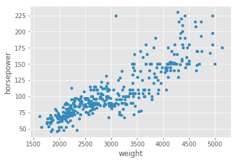

```python
df.plot.scatter(x='weight',y='horsepower')
```

The more weight of the car, the higher the horsepower. This makes sense, as more horsepower is required to get a larger vehicle moving.

## (F) Suppose that we wish to predict gas mileage on the basis of the other variables. Do your plots suggest that any of the other variables might be useful in predicting mpg? Justify your answer.

[output not shown]

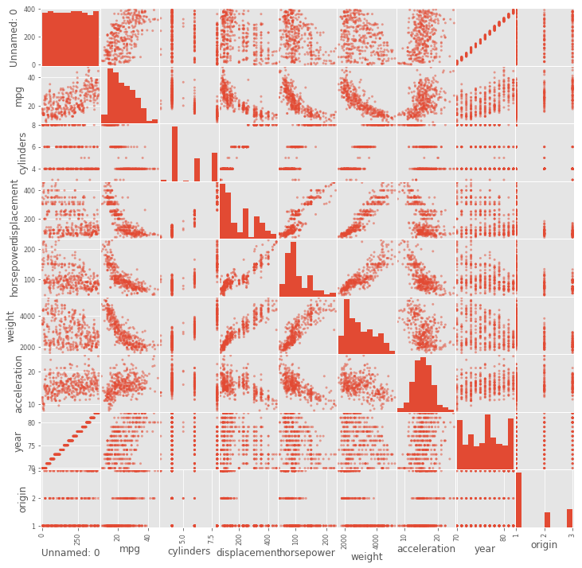

```python
pd.plotting.scatter_matrix(df,figsize=(12,12))
```

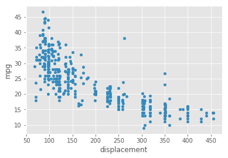

```python
df.plot.scatter(x='displacement',y='mpg')
```

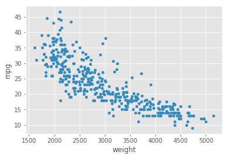

```python
df.plot.scatter(x='weight',y='mpg')
```

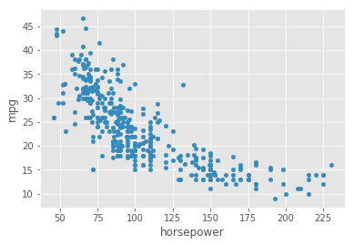

```python
df.plot.scatter(x='horsepower',y='mpg')
```

ANS:

I would suggest that the horsepower, weight, and displacement variables are good predictors of mpg. Each have a strong (negative) correlation to mpg. This suggests that if any of these three variables increase, mpg decreases.